# p8131_hw7_xy2395

Jack Yan

4/11/2019

```r
# Import data
polite_df <-
  read_csv('../hw7/HW7-politeness_data.csv') %>%
  as.tibble() %>% janitor::clean_names()
```

#### 1. Exploratory Analysis

Provide boxplots to show the relation between gender/attitude and pitch.

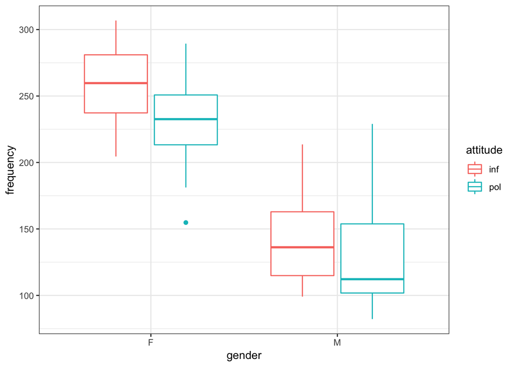

```r
# boxplots
polite_df %>%
  ggplot(aes(x = gender, y = frequency, color = attitude)) +
    geom_boxplot() +
    theme_bw()
```

Males generally tend to have lower pitch than females. Within each gender, informal attitude (inf) tends to have higher pitch than formal attitude (pol).

#### 2. Mixed Effects Model with Random Intercept

Fit a mixed effects model with random intercepts for different subjects (gender and attitude being the fixed effects).

```r
lmm = lme(frequency ~ gender + attitude, random = ~1 | subject, method = "REML", data = polite_df)

VarCorr(lmm)
```

```
## subject = pdLogChol(1)
##             Variance StdDev
## (Intercept) 598.1953 24.45803
## Residual    847.7049 29.11537
```

```r
# var(Yi) = 598.1953 + 847.7049 = 1445.9
var = as.numeric(VarCorr(lmm)[[1]]) + as.numeric(VarCorr(lmm)[[2]]); var
```

```
## [1] 1445.9
```

```r
# cov(Yij,Yik) = 598.2
cov = as.numeric(VarCorr(lmm)[[1]]); cov
```

```
## [1] 598.1953
```

The covariance matrix for a subject $Y_i$ follows a compound symmetry pattern with $var(Y_{ij})=1445.9$ and $cov(Y_{ij},Y_{ik})=598.2$. There are 14 measurements within each subject, so the covariance matrix is a 14*14 matrix with $var(Y_{ij})=1445.9$ as diagonal values and $cov(Y_{ij},Y_{ik})=598.2$ as off-diagonal values.

```r
# covariance matrix for the REML estimates of fixed effects
vcov(lmm)
```

```
##             (Intercept)       genderM   attitudepol
## (Intercept)   229.67362 -2.195819e+02 -2.018345e+01
## genderM      -219.58189  4.391638e+02  6.451438e-15
## attitudepol   -20.18345  6.451438e-15  4.036690e+01
```

The covariance matrix for the REML estimates of fixed effects is shown above.

```r
# BLUPs for subject-specic intercepts
random.effects(lmm)
```

```
##    (Intercept)
## F1  -13.575831
## F2   10.170522
## F3    3.405309
## M3   27.960288
## M4    4.739325
## M7  -32.699613
```

The BLUPs for subject-specific intercepts are shown above.

```r
resid_lmm = polite_df$frequency-fitted(lmm)[[1]]
resid_lmm
```

[output not shown]

#### 3. Likelihood Ratio Test for the Interaction Term

Fit a mixed effects model with intercepts for different subjects (gender, attitude and their interaction being the fixed effects).

```r
lmm_small = lme(frequency ~ gender + attitude, random = ~1 | subject, method = "ML", data = polite_df)
lmm_large = lme(frequency ~ gender * attitude, random = ~1 | subject, method = "ML", data = polite_df)

anova(lmm_small, lmm_large)
```

```
##           Model df      AIC      BIC    logLik   Test  L.Ratio p-value
## lmm_small     1  5 825.6363 837.7904 -407.8182
## lmm_large     2  6 826.2508 840.8357 -407.1254 1 vs 2 1.385523  0.2392
```

We use maximum likelihood method to fit the model. The p-value for Likelihood ratio test is 0.2392 > 0.05, so we fail to reject the null and conclude that the interaction term is not significantly associated with pitch, at the significance level of 0.05.

#### 4. Mixed Effects Model with Random Intercept and Slope

Model: $Y_{ij}=\beta_1 + \beta_2*gender+\beta_3*I(attitude=pol)+b_{1i}+b_{2i}*I(attitude=pol)+ \epsilon_{ij}$,

where $\beta_1$ and $\beta_2$ are fixed intercept and slope, respectively, and $b_{1i}$ and $b_{2i}$ are random intercept and slope, respectively.

```r
lmm2 = lme(frequency ~ gender + attitude, random = ~1 + attitude | subject, method = "REML", data = polite_df)

VarCorr(lmm2)
```

```
## subject = pdLogChol(1 + attitude)
##             Variance     StdDev       Corr
## (Intercept) 5.981953e+02 24.458032213 (Intr)
## attitudepol 1.079496e-05  0.003285569 0
## Residual    8.477049e+02 29.115372269
```

We get $g_{11}=598.2$, $g_{22}=1.079496*10^{-5}$, $g_{12}=0$, and $\sigma^2=847.7$.

$var(Y_{ij})=g_{11} + 2t_{ij}g_{12} + t_{ij}^2 g_{22} + \sigma^2$

$cov(Y_{ij},Y_{ik})=g_{11}+ (t_{ij} + t_{ik})g_{12} +t_{ij}t_{ik}g_{22}$

Since $g_{22}$ is small and $t_{ij}$ can be either 0 or 1, we ignore the terms $t_{ij}^2 g_{22}$ and $t_{ij}t_{ik}g_{22}$.

So we get $var(Y_{ij})= 1445.9$ and $cov(Y_{ij},Y_{ik})=598.2$ for any different j and k.

The random slope has small variance, thus captures little variation in the data. So we could reduce this model to a random intercept model. The covariance structure for this model is thus approxiamtely a compound symmetry structure as in Question 2.

```r
fixed.effects(lmm2)
```

```
## (Intercept)     genderM attitudepol
##   256.98691  -108.79762   -20.00238
```

```r
fixed_effect = 256.98691 + -20.00238; fixed_effect
```

```
## [1] 236.9845
```

```r
random.effects(lmm2)
```

```
##    (Intercept)   attitudepol
## F1  -13.575831 -8.408891e-07
## F2   10.170522  1.499413e-07
## F3    3.405308 -2.981919e-07
## M3   27.960288  1.009764e-06
## M4    4.739325  7.794162e-07
## M7  -32.699612 -8.000404e-07
```

```r
random_effect = -13.575831 + -8.408891 * 10^(-07); random_effect
```

```
## [1] -13.57583
```

```r
BLUP = fixed_effect + random_effect; BLUP
```

```
## [1] 223.4087
```

#### 5.